# Proyecto2PersonalRafa

Rafael León

August 29, 2018

# 1 Situacion Problematica

No se ha buscado la relacion entre habilidades cognitivas, crecimiento y salud de los huesos utilizando los datos del estudio longitudinal de la UVG y los estudios que se han realizado con datos parecidos no han sido bien investigados en paises de bajos y medianos ingresos.

Los datos utilizados para este analisis son el producto de un estudio longitudinal diseñado por el Dr. Barry Bogin hace mas de 50 años en conjunto con el Colegio Americano de Guatemala. Ellos se propusieron a colectar datos longitudinalmente de estudiantes de todos los años y darle seguimiento a su crecimiento de forma anual hasta el momento en el que completaban sus estudios de bachillerato.  
El estudio se expandió a 6 colegios más a lo largo de los años y se cuenta con datos de peso, talla, IQ, pruebas de lectura y masa osea para registros comenzando en el año 1953.

Esta base de datos pertenece a la fundación Bill and Melinda Gates, los cuales donaron los fondos necesarios para digitalizarla.

# 2 Problema Cientifico

Los niños guatemaltecos no cumplen con los indicadores de peso y talla a nivel mundial. A pesar de que se han realizado estudios que muestran que niños guatemaltecos viviendo en el extranjero si cumplen con estas tallas.

## 2.1 Objetivos

Determinar si se pueden hacer predicciones de peso y/o talla para niños guatemaltecos utilizando la base de datos del estudio longitudinal DNL del colegio americano y adjuntos. Con el proposito de comparar predicciones de peso y talla nacional con datos internacionales.

- Realizar un analisis exploratorio de los datos para determinar la forma apropiada de diseñar el modelo predictivo sugerido.

# 3 Conjunto de datos

## 3.1 Leyendo Datos

- Subjects: Informacion personal de cada sujeto de prueba.
- Card1: Informacion fisiologica de los sujetos.
- Card2: Informacion fisiologica complementaria.

```r
subjects = as.data.table(read_xlsx("./data/1-Subjects sex_ID_school_DOB.xlsx"))
card1 = as.data.table(read_xlsx("./data/4-Card1.xlsx"))
card2 = as.data.table(read_xlsx("./data/5-Card2.xlsx"))
```

### 3.1.1 Union y Limpieza de Datos

Uniremos cada conjunto de datos con la informacion respectiva de cada sujeto de observacion. Para eso las uniremos basandonos en el ID.

Leer datos de subjects, card1 y card2:

```r
mainData <- as.data.frame(read_xlsx("./data/1-Subjects sex_ID_school_DOB.xlsx"))
c1 <-  as.data.frame(read_xlsx("./data/4-Card1.xlsx"))
c2 <-  as.data.frame(read_xlsx("./data/5-Card2.xlsx"))
```

Modificar los nombres de columnas y union de bases de datos:

```r
colnames(mainData)[1] <- "Id"
colnames(c1)[2] <- "date"
colnames(c2)[2] <- "date"

cards <- merge(c1, c2, by = c("Id", "date"))
completeData <- merge(mainData, cards, by = "Id")
completeData$age <- round(completeData$date - completeData$`DOB decimal`, 0)
```

### 3.1.2 Subject

`Subject` es el conjunto de datos que uniremos con los datos recopilados en `Card1` y `Card2`. La limpieza en este conjunto de datos sera tan simple como volver *Factores* las variables `Sex`, `IdSchool 1` y el `ID` del sujeto de observacion. Por otro lado desecharemos `IdSchool 2` que solo representa un valor booleano donde es `TRUE` si el estudiante cambio de colegio.

```r
subSubject = subjects[,c(1:5)]
subSubject$Sex = as.factor(subSubject$Sex)
subSubject$`IdSchool 1` = as.factor(subSubject$`IdSchool 1`)
subSubject$ID = as.factor(subSubject$ID)
```

### 3.1.3 Subject-Card1

Uniremos `Card1` con `Subject` por medio del `ID`. Para poder combinar ambos conjuntos de datos realizaremos lo siguiente en `Card1`:

- Desecharemos las variables `entering date`, `User`, `RepetitionCard1`.
- Renombraremos `Id` como `ID`.
- Convertir a *factor* `ID`.
- Convertir a *factor* `gradeCard1`.
- Por ultimo combinamos ambos conjuntos de datos.

```r
subCard1 = card1[,c(1:7)]
names(subCard1)[1] = "ID"
subCard1$ID = as.factor(subCard1$ID)
subCard1$gradeCard1 = as.factor(subCard1$gradeCard1)

Card1 = merge(subSubject,subCard1)
Card1 = na.omit(Card1)

Card1$`Hand grip` = as.numeric(Card1$`Hand grip`)
Card1$edad = round(Card1$yearCard1-Card1$`DOB decimal`,0)
```

### 3.1.4 Subject-Card2

Uniremos `Card2` con `Subject` por medio del `ID`. Para poder combinar ambos conjuntos de datos realizaremos lo siguiente en `Card2`:

- Desecharemos las variables `entering date`, `User`, `Repetition`.
- Renombraremos `Id` como `ID`.
- Convertir a *factor* `ID`.
- Convertir a *factor* `gradeCard2`.
- Por ultimo combinamos ambos conjuntos de datos.

# 4 Analisis Exploratorio

## 4.1 Card1

### 4.1.1 Descripcion de Variables

En Card1 podemos encontrar las siguientes caracteristicas fisiologicas de los sujetos de observacion.

- `ID`: Identificador personal para cada persona involucrada en el set de datos.
- `DOB`: Fecha de nacimiento de la persona.
- `DOB decimal`: Año de nacimiento de la persona en representacion decimal.
- `Sex`: Sexo de la persona.
- `IdScholl 1`: Identificador del colegio al que asistio la persona.
- `yearCard1`: Año en el que se recopilaron los datos.
- `gradeCard1`: Grado escolar al que pertenec?a la persona.
- `Height`: Altura de la persona en centimetros.
- `Weight`: Peso de la persona en kg.
- `Hand grip`: Fuerza de la mano calculado en kg.
- `Dental`: Denticion piezas del sujeto. Numero de piezas permanentes eruptadas.
- `Edad`: Edad del sujeto.

### 4.1.2 Resumen de Variables

```r
head(Card1)
```

```
##       ID        DOB DOB decimal Sex IdSchool 1 yearCard1 gradeCard1 Height
## 1: 10001 1947-11-27        47.9   M          1     53.17          1    113
## 2: 10001 1947-11-27        47.9   M          1     54.18          2    116
## 3: 10001 1947-11-27        47.9   M          1     55.18         11    121
## 4: 10001 1947-11-27        47.9   M          1     56.18         11    125
## 5: 10001 1947-11-27        47.9   M          1     57.17         12    131
## 6: 10001 1947-11-27        47.9   M          1     58.17         13    136
##    Weight Hand grip Dental edad
## 1:   21.8       287      0    5
## 2:   22.2         1      0    6
## 3:   24.5         7      0    7
## 4:   27.2         8      0    8
## 5:   29.0        14      0    9
## 6:   32.2        12      0   10
```

```r
summary(Card1)
```

```
##        ID              DOB                       DOB decimal    Sex
##  10162  :    14   Min.   :1939-05-20 00:00:00   Min.   :39.38   F:67752
##  10226  :    14   1st Qu.:1961-07-15 06:00:00   1st Qu.:61.53   M:89394
##  10243  :    14   Median :1969-09-29 12:00:00   Median :69.74
##  10275  :    14   Mean   :1970-01-01 15:18:53   Mean   :70.00
##  10281  :    14   3rd Qu.:1978-03-02 00:00:00   3rd Qu.:78.17
##  10313  :    14   Max.   :1994-04-16 00:00:00   Max.   :94.29
##  (Other):157062
##  IdSchool 1   yearCard1       gradeCard1        Height
##  1:42283    Min.   :53.17   11     :27094   Min.   : 93.0
##  2:28136    1st Qu.:73.20   12     :23931   1st Qu.:124.0
##  3:23492    Median :81.19   14     :21946   Median :137.5
##  4: 6709    Mean   :81.15   16     :19473   Mean   :139.0
##  5:41196    3rd Qu.:90.10   21     :15264   3rd Qu.:153.5
##  6: 2418    Max.   :99.29   23     :12101   Max.   :287.0
##  7:12912                    (Other):37337
##      Weight         Hand grip          Dental             edad
##  Min.   : 11.40   Min.   :  0.00   Min.   :  0.000   Min.   : 4.00
##  1st Qu.: 25.00   1st Qu.: 11.00   1st Qu.:  0.000   1st Qu.: 8.00
##  Median : 33.60   Median : 16.00   Median :  0.000   Median :11.00
##  Mean   : 37.43   Mean   : 19.43   Mean   :  4.908   Mean   :11.15
##  3rd Qu.: 47.70   3rd Qu.: 24.00   3rd Qu.:  8.000   3rd Qu.:13.00
##  Max.   :287.00   Max.   :287.00   Max.   :287.000   Max.   :33.00
##
```

### 4.1.3 Cruce de Variables

Veamos que variables tienen relacion entre si con ayuda de las correlacion representadas con heatmaps.

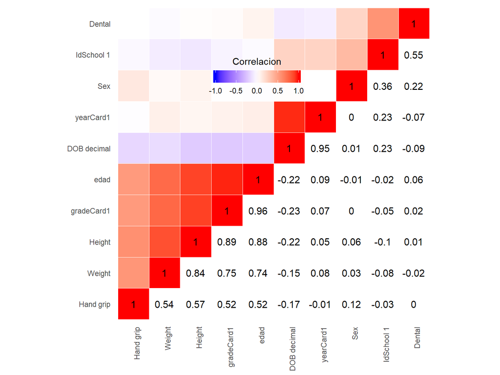

```r
datos = Card1[,c(3:12)]
datos$Sex = as.factor(datos$Sex)
datos$Sex = as.numeric(datos$Sex)
datos$`IdSchool 1` = as.numeric(datos$`IdSchool 1`)
datos$gradeCard1 = as.numeric(datos$gradeCard1)

#Obtener matriz de correlacion
cormat = round(cor(datos,use = "complete.obs"),2)
#Reordenar matriz de correlacion
reorder_cormat <- function(cormat){
# Use correlation between variables as distance
dd <- as.dist((1-cormat)/2)
hc <- hclust(dd)
cormat <-cormat[hc$order, hc$order]
}
cormat = reorder_cormat(cormat)
#Obtener triangulo superior
get_upper_tri = function(cormat){
  cormat[lower.tri(cormat)] = NA
  return(cormat)
}
upper_tri = get_upper_tri(cormat)
#Correlacion como heatmap
require(reshape2)
melted_cormat = melt(upper_tri, na.rm = T)
require(ggplot2)
ggheatmap = ggplot(data = melted_cormat, aes(x=Var1, y=Var2, fill = value)) + geom_tile(color = "white") + scale_fill_gradient2(low = "blue",high = "red",mid = "white", midpoint = 0, limit = c(-1,1), space = "Lab", name="Correlacion") + theme_minimal() + theme(axis.text.x = element_text(angle = 90, vjust = 1,hjust = 1)) + coord_fixed()

ggheatmap +
geom_text(aes(Var2, Var1, label = value), color = "black", size = 4) +
theme(
  axis.title.x = element_blank(),
  axis.title.y = element_blank(),
  panel.grid.major = element_blank(),
  panel.border = element_blank(),
  panel.background = element_blank(),
  axis.ticks = element_blank(),
  legend.justification = c(1, 0),
  legend.position = c(0.6, 0.7),
  legend.direction = "horizontal")+
  guides(fill = guide_colorbar(barwidth = 7, barheight = 1,
                title.position = "top", title.hjust = 0.5))
```

### 4.1.4 Cluster

```r
library(factoextra)
cluster = Card1[complete.cases(Card1),c(3,4,5,7:12)]
cluster = unique(cluster)
cluster$Sex = as.factor(cluster$Sex)
cluster$Sex = as.numeric(cluster$Sex)
cluster$`IdSchool 1` = as.numeric(cluster$`IdSchool 1`)
cluster$gradeCard1 = as.numeric(cluster$gradeCard1)

set.seed(12)

cluster[is.na(cluster)] = 0
wss <- (nrow(cluster[,c()])-1)*sum(apply(cluster[,1:ncol(cluster)],2,var))

for (i in 2:10)
  wss[i] <- sum(kmeans(cluster[,1:ncol(cluster)], centers=i)$withinss)
```

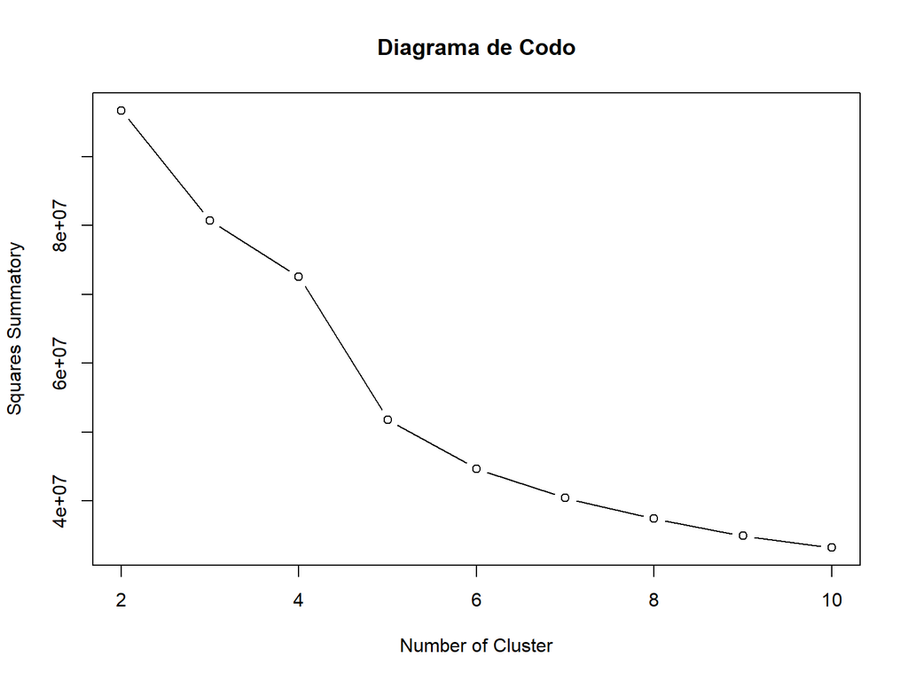

```r
plot(2:
       10, wss[c(2:10)], type="b", xlab="Number of Cluster",  ylab="Squares Summatory", main = "Diagrama de Codo")
```

Gracias al diagrama de codo, se considera 5 como la cantidad optima de grupos a realizar. Para realizar el clustering utilizaremos la tecnica de K-medias.

```r
require("fpc")
```

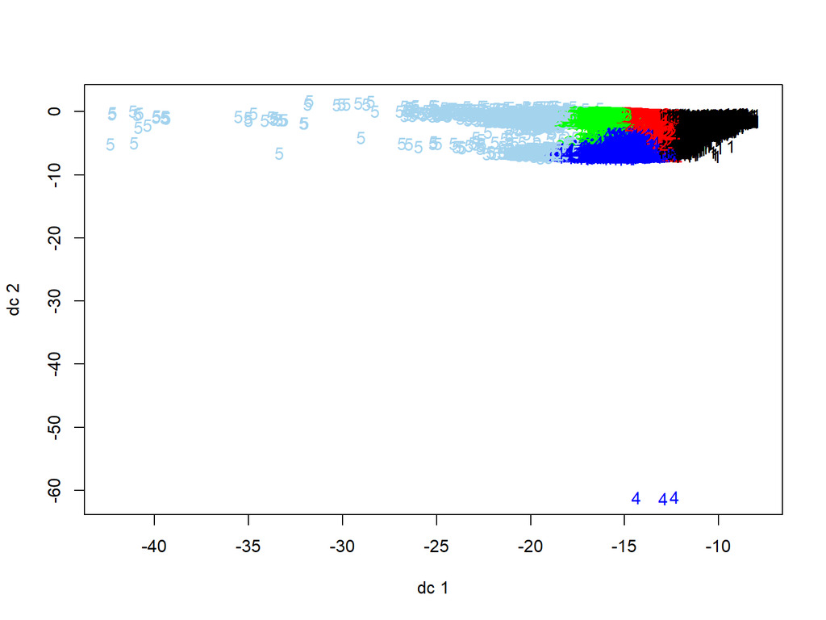

```r
set.seed(90)
km = kmeans(cluster, 5)
cluster$grupo<-km$cluster

plotcluster(cluster[,c(1:9)],cluster$grupo)
```

Ahora que ya tenemos los clusters realizados, analicemos como los datos fueron agrupados. Debido a que las variables son cuantitativas y por temas de percepcio, utilizaremos los *boxplots* para identificar como difieren las distintas variables entre grupos.

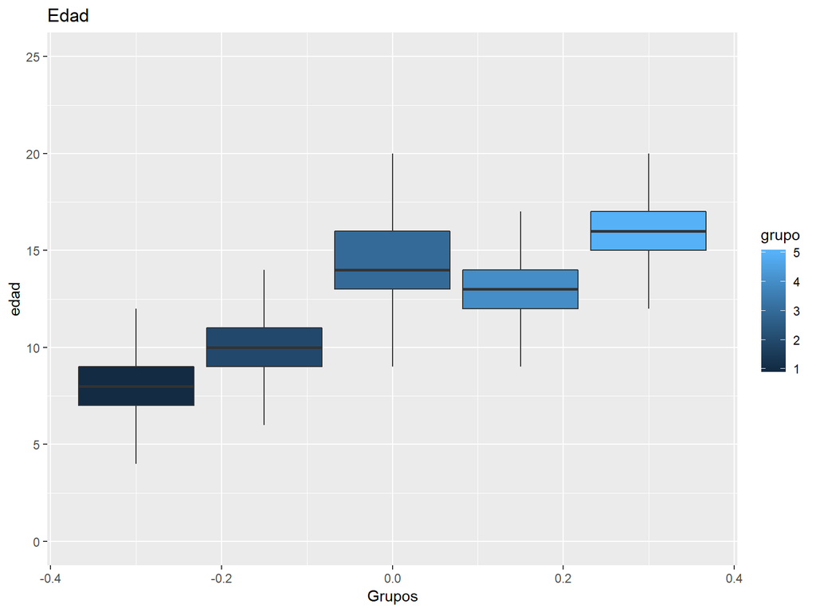

```r
ggplot(data = cluster, aes(group = grupo, y = edad, fill = grupo)) + geom_boxplot(outlier.shape = NA) + xlab("Grupos") + ggtitle("Edad") + ylim(c(0,25))
```

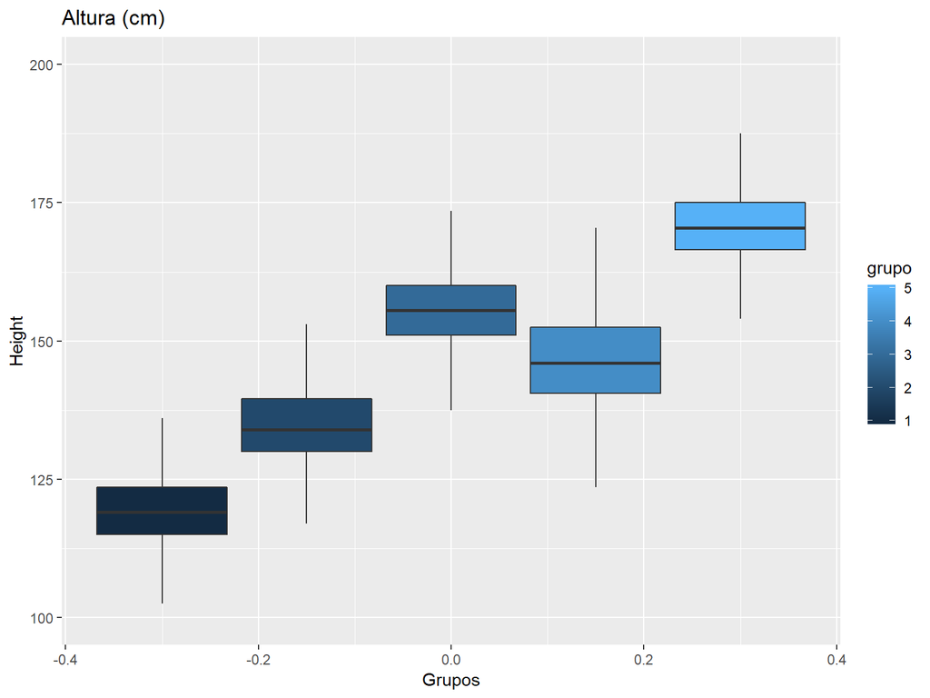

```r
ggplot(data = cluster, aes(group = grupo, y = Height, fill = grupo)) + geom_boxplot(outlier.shape = NA) + xlab("Grupos") + ggtitle("Altura (cm)") + ylim(c(100,200))
```

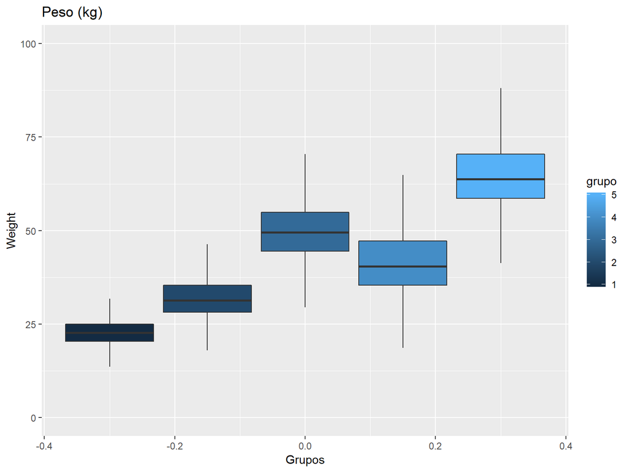

```r
ggplot(data = cluster, aes(group = grupo, y = Weight, fill = grupo)) + geom_boxplot(outlier.shape = NA) + xlab("Grupos") + ggtitle("Peso (kg)") + ylim(c(0,100))
```

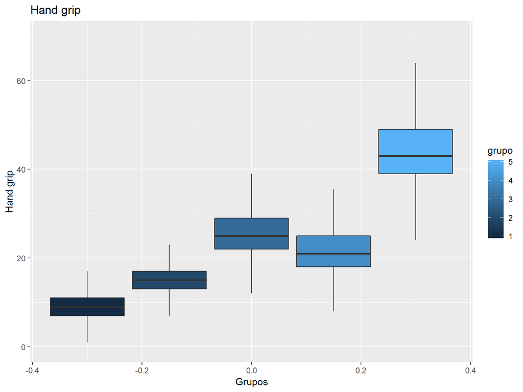

```r
ggplot(data = cluster, aes(group = grupo, y = `Hand grip`, fill = grupo)) + geom_boxplot(outlier.shape = NA) + xlab("Grupos") + ggtitle("Hand grip") + ylim(c(0,70))
```

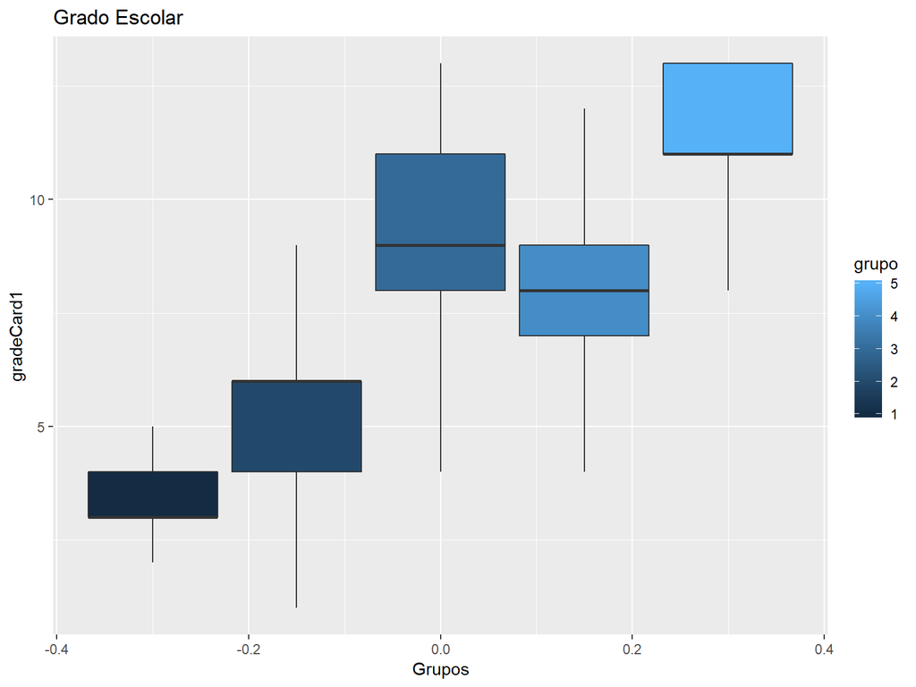

```r
ggplot(data = cluster, aes(group = grupo, y = gradeCard1, fill = grupo)) + geom_boxplot(outlier.shape = NA) + xlab("Grupos") + ggtitle("Grado Escolar")
```

Ademas de que los graficos demuestran que las edades son una variable fuerte para decidir la pertenencia a un grupo, tambien demuestra la relacion que tiene con las demas variables. Las demas variables cambian proporcionalmente a la edad, lo que se puede reflejar en la matriz de correlaciones presentada anteriormente.

## 4.2 Card2

### 4.2.1 Descripcion de Variables

- `ID`: Identificador personal para cada persona involucrada en el set de datos.
- `DOB`: Fecha de nacimiento de la persona.
- `DOB decimal`: Año de nacimiento de la persona en representacion decimal.
- `Sex`: Sexo de la persona.
- `IdScholl 1`: Identificador del colegio al que asistio la persona.
- `yearCard2`: Año en el que se recopilaron los datos.
- `grade Card 2`: Grado escolar al que pertenec?a la persona.
- `UAC1`: Circunferencia Tricep 1
- `UAC2`: Circunferencia Tricep 2
- `TST1`: Pliegue Cut?neo Tricep 1
- `TST2`: Pliegue Cut?neo Tricep 2
- `SSF1`: Pliegue Cut?neo Subescapular 1
- `SSF2`: Pliegue Cut?neo Subescapular 2
- `Edad`: Edad del sujeto.

### 4.2.2 Resumen de Variables

```r
head(Card2)
```

```
##       ID        DOB DOB decimal Sex IdSchool 1 yearCard2 grade Card 2
## 1: 10605 1954-05-18       54.38   M          1     72.19           25
## 2: 10608 1954-01-09       54.02   F          1     72.19           25
## 3: 10647 1954-06-18       54.46   M          1     72.19           25
## 4: 10659 1953-11-18       53.87   F          1     72.19           25
## 5: 10704 1954-02-09       54.11   M          1     72.19           25
## 6: 10708 1954-09-11       54.69   M          1     72.20           24
##    UAC1 cm UAC2 cm TST1 mm TST2 mm SSF1 mm SSF2 mm edad
## 1:       0       0       8       8      11      11   18
## 2:       0       0      12      12      14      13   18
## 3:       0       0       8       8       9       9   18
## 4:       0       0      19      19      17      17   18
## 5:       0       0      17      15      18      17   18
## 6:       0       0       6       6       8       8   18
```

```r
summary(Card2)
```

```
##        ID             DOB                       DOB decimal    Sex
##  12571  :   13   Min.   :1950-03-17 00:00:00   Min.   :50.21   F:43222
##  12599  :   13   1st Qu.:1970-04-24 00:00:00   1st Qu.:70.31   M:56655
##  12624  :   13   Median :1975-08-21 00:00:00   Median :75.63
##  12669  :   13   Mean   :1976-01-12 21:49:46   Mean   :76.03
##  12704  :   13   3rd Qu.:1982-03-05 00:00:00   3rd Qu.:82.18
##  12711  :   13   Max.   :1994-04-16 00:00:00   Max.   :94.29
##  (Other):99799
##  IdSchool 1   yearCard2      grade Card 2      UAC1 cm
##  1:28643    Min.   :71.19   11     :18375   Min.   : 0.00
##  2:15925    1st Qu.:81.30   12     :16463   1st Qu.:18.00
##  3:14239    Median :87.14   14     :15802   Median :20.50
##  4: 2280    Mean   :87.24   16     :14226   Mean   :20.36
##  5:23519    3rd Qu.:93.23   21     :10713   3rd Qu.:24.00
##  6: 2399    Max.   :99.32   23     : 8452   Max.   :43.00
##  7:12872                    (Other):15846
##     UAC2 cm         TST1 mm         TST2 mm         SSF1 mm
##  Min.   : 0.00   Min.   : 2.00   Min.   : 2.00   Min.   : 0.00
##  1st Qu.:18.00   1st Qu.: 8.00   1st Qu.: 7.00   1st Qu.: 6.00
##  Median :20.50   Median :11.00   Median :10.00   Median : 8.00
##  Mean   :20.35   Mean   :11.81   Mean   :11.75   Mean   :10.26
##  3rd Qu.:24.00   3rd Qu.:15.00   3rd Qu.:15.00   3rd Qu.:13.00
##  Max.   :42.50   Max.   :48.00   Max.   :45.00   Max.   :55.00
##
##     SSF2 mm           edad
##  Min.   : 0.00   Min.   : 4.0
##  1st Qu.: 6.00   1st Qu.: 8.0
##  Median : 8.00   Median :11.0
##  Mean   :10.22   Mean   :11.2
##  3rd Qu.:13.00   3rd Qu.:14.0
##  Max.   :55.00   Max.   :33.0
##
```

### 4.2.3 Cruce de Variables

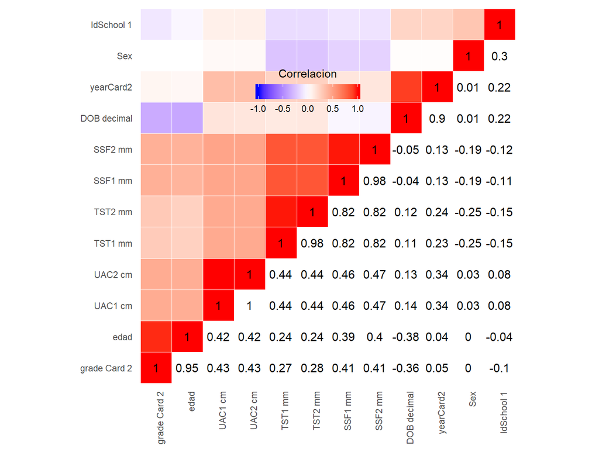

```r
datos2 = Card2[,c(3:14)]
datos2$Sex = as.numeric(datos2$Sex)
datos2$`IdSchool 1` = as.numeric(datos2$`IdSchool 1`)
datos2$`grade Card 2` = as.numeric(datos2$`grade Card 2`)

#Obtener matriz de correlacion
cormat = round(cor(datos2,use = "complete.obs"),2)
#Reordenar matriz de correlacion
reorder_cormat <- function(cormat){
# Use correlation between variables as distance
dd <- as.dist((1-cormat)/2)
hc <- hclust(dd)
cormat <-cormat[hc$order, hc$order]
}
cormat = reorder_cormat(cormat)
#Obtener triangulo superior
get_upper_tri = function(cormat){
  cormat[lower.tri(cormat)] = NA
  return(cormat)
}
upper_tri = get_upper_tri(cormat)
#Correlacion como heatmap
require(reshape2)
melted_cormat = melt(upper_tri, na.rm = T)
require(ggplot2)
ggheatmap = ggplot(data = melted_cormat, aes(x=Var1, y=Var2, fill = value)) + geom_tile(color = "white") + scale_fill_gradient2(low = "blue",high = "red",mid = "white", midpoint = 0, limit = c(-1,1), space = "Lab", name="Correlacion") + theme_minimal() + theme(axis.text.x = element_text(angle = 90, vjust = 1,hjust = 1)) + coord_fixed()

ggheatmap +
geom_text(aes(Var2, Var1, label = value), color = "black", size = 4) +
theme(
  axis.title.x = element_blank(),
  axis.title.y = element_blank(),
  panel.grid.major = element_blank(),
  panel.border = element_blank(),
  panel.background = element_blank(),
  axis.ticks = element_blank(),
  legend.justification = c(1, 0),
  legend.position = c(0.6, 0.7),
  legend.direction = "horizontal")+
  guides(fill = guide_colorbar(barwidth = 7, barheight = 1,
                title.position = "top", title.hjust = 0.5))
```

En la matriz de correlacion podemos ver que cada par de variables que se miden como 1 y 2, se representan una a la otra. Esto nos permite descartarlas para futuros modelos. Por otro lado, el sexo y el colegio son las variables con menos relacion respecto a las otras.

### 4.2.4 Cluster

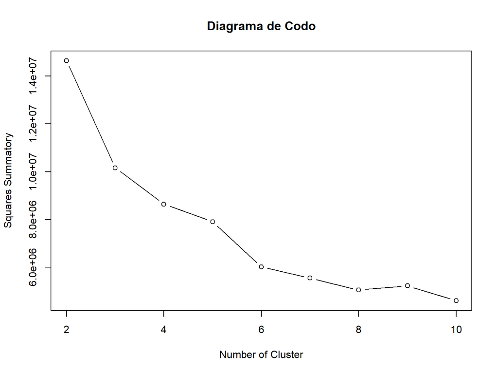

```r
cluster = unique(Card2[,c(3,4,5,7,8,10,13,14)])
cluster$Sex = as.numeric(cluster$Sex)
cluster$`IdSchool 1` = as.numeric(cluster$`IdSchool 1`)
cluster$`grade Card 2` = as.numeric(cluster$`grade Card 2`)

set.seed(543)
wss <- (nrow(cluster[,c()])-1)*sum(apply(cluster[,1:ncol(cluster)],2,var))

for (i in 2:10)
  wss[i] <- sum(kmeans(cluster[,1:ncol(cluster)], centers=i)$withinss)

plot(2:
       10, wss[c(2:10)], type="b", xlab="Number of Cluster",  ylab="Squares Summatory", main = "Diagrama de Codo")
```

Propongo 3 o 4 como la cantidad de cluster a realizar. Realizaremos el modelo de k-medias con k = 4 de primero, ya que existe la sospecha de que k = 3 sera la cantidad correcta.

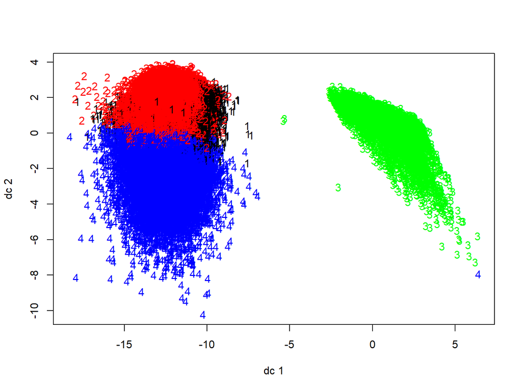

```r
set.seed(91)

km<-kmeans(cluster,4)
cluster$grupo<-km$cluster

plotcluster(cluster[,c(1:8)],km$cluster)
```

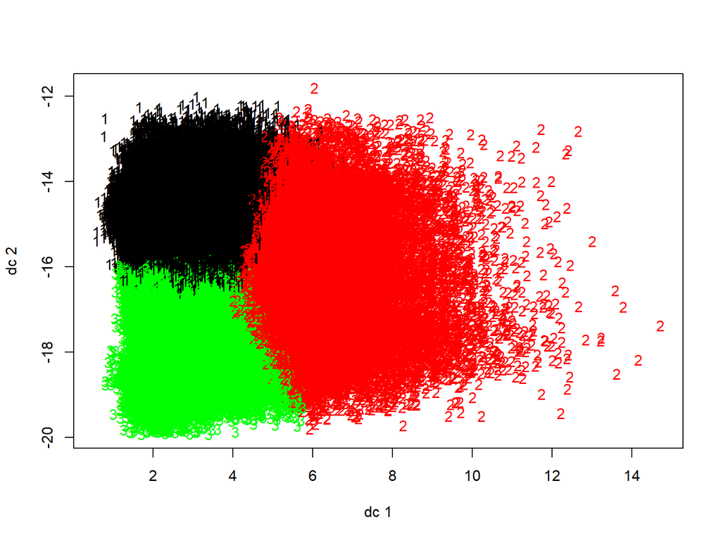

```r
km<-kmeans(cluster,3)
cluster$grupo<-km$cluster

plotcluster(cluster[,c(1:8)],km$cluster)
```

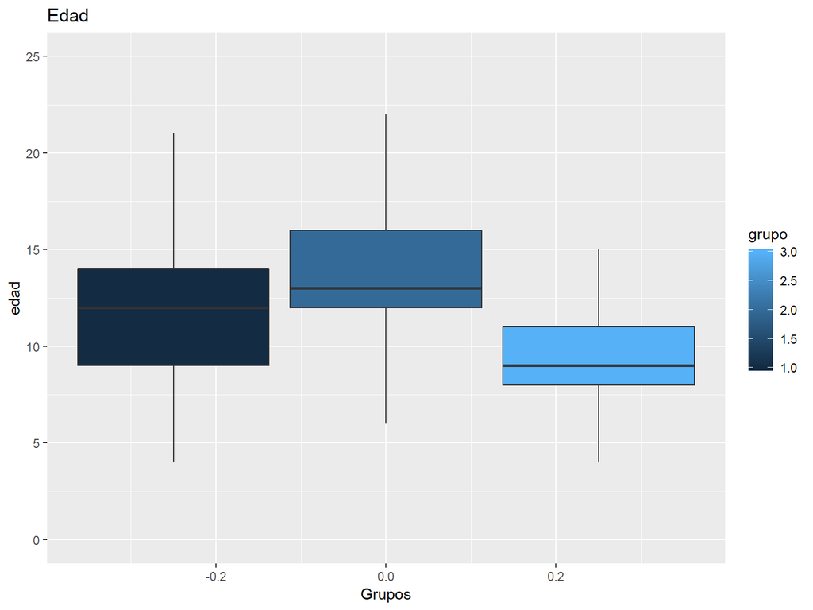

```r
ggplot(data = cluster, aes(group = grupo, y = edad, fill = grupo)) + geom_boxplot(outlier.shape = NA) + xlab("Grupos") + ggtitle("Edad") + ylim(c(0,25))
```

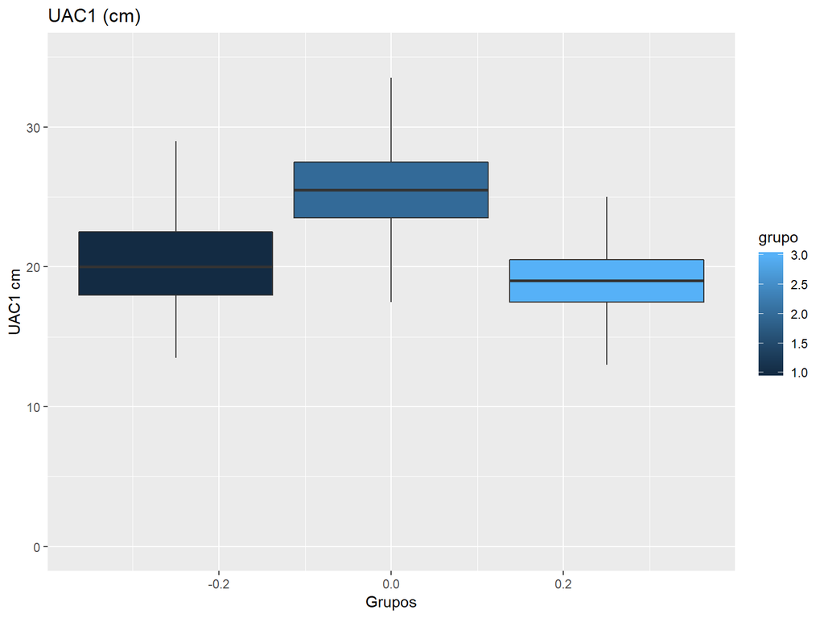

```r
ggplot(data = cluster, aes(group = grupo, y = `UAC1 cm`, fill = grupo)) + geom_boxplot(outlier.shape = NA) + xlab("Grupos") + ggtitle("UAC1 (cm)") + ylim(c(0,35))
```

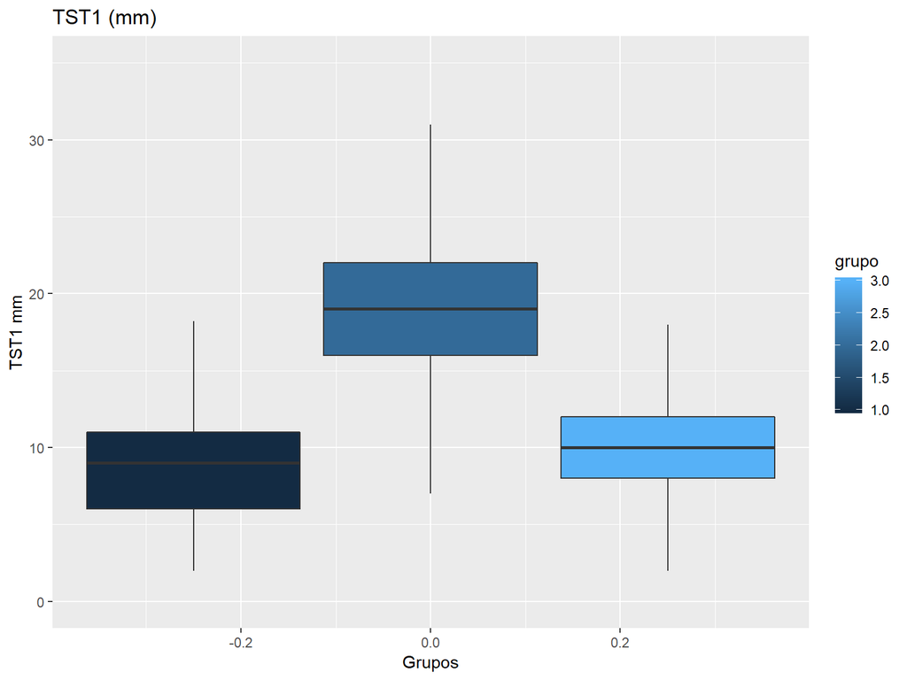

```r
ggplot(data = cluster, aes(group = grupo, y = `TST1 mm`, fill = grupo)) + geom_boxplot(outlier.shape = NA) + xlab("Grupos") + ggtitle("TST1 (mm)") + ylim(c(0,35))
```

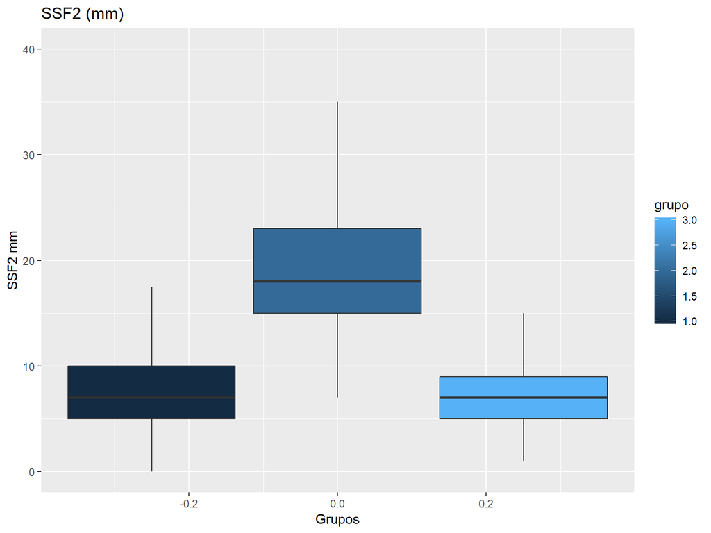

```r
ggplot(data = cluster, aes(group = grupo, y = `SSF2 mm`, fill = grupo)) + geom_boxplot(outlier.shape = NA) + xlab("Grupos") + ggtitle("SSF2 (mm)") + ylim(c(0,40))
```

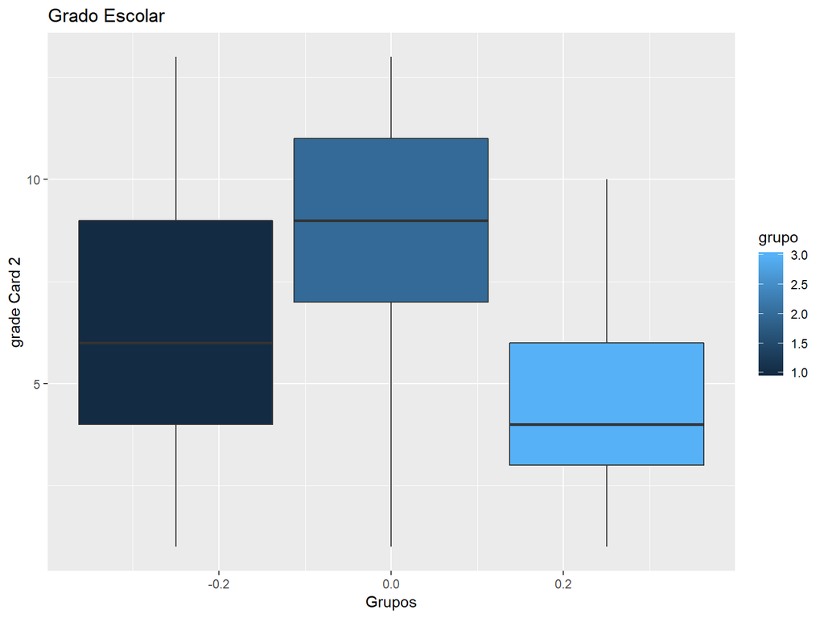

```r
ggplot(data = cluster, aes(group = grupo, y = `grade Card 2`, fill = grupo)) + geom_boxplot(outlier.shape = NA) + xlab("Grupos") + ggtitle("Grado Escolar")
```

Podemos ver que el grupo mas diferente es el Grupo 2, mientras que el Grupo 1 y el 3 son muy parecidos. La distribucion de `SSF2`, `UAC1` y `TST1` son muy similares pero lo que marca la diferencia entre ellos es la `edad` y el `grade Card 2`. Donde el Grupo 1 es un grupo con edades mayores que las del grupo 3. En orden descendiente ordeno los grupos de la siguiente manera.

1. Grupo 2
2. Grupo 1
3. Grupo 3

## 4.3 Graficos Exploratorios

#### 4.3.0.1 Exploracion de variables y elminacion de outliers

Grafica de frecuencia de edades:

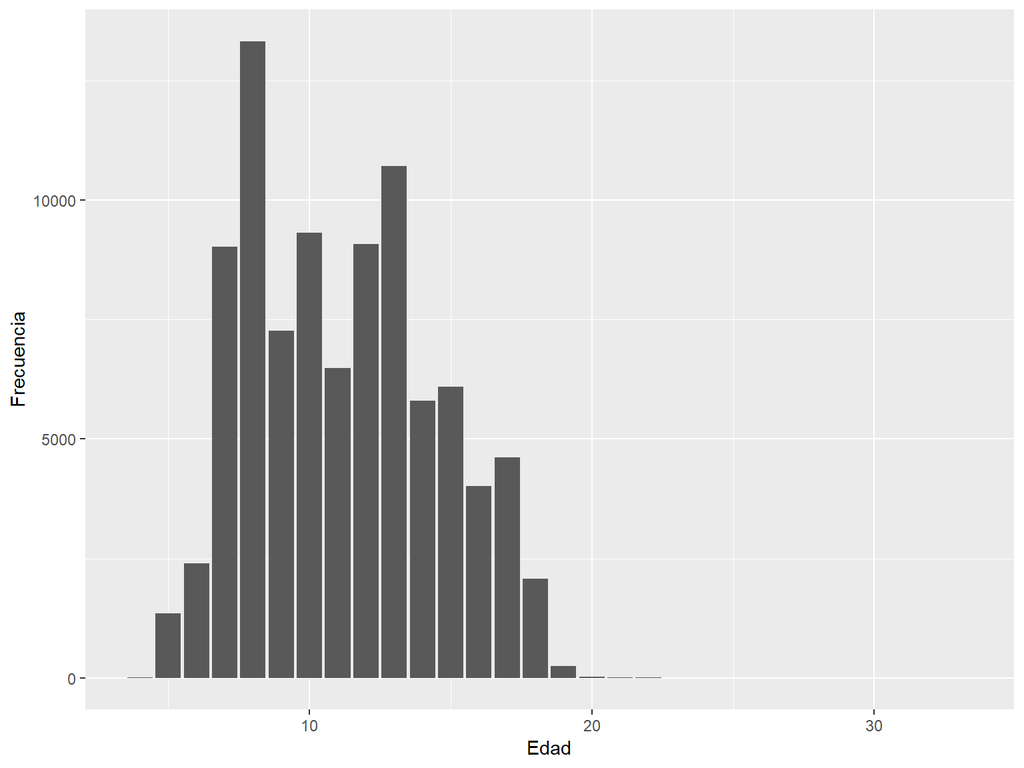

Boxplots de altura por edad:

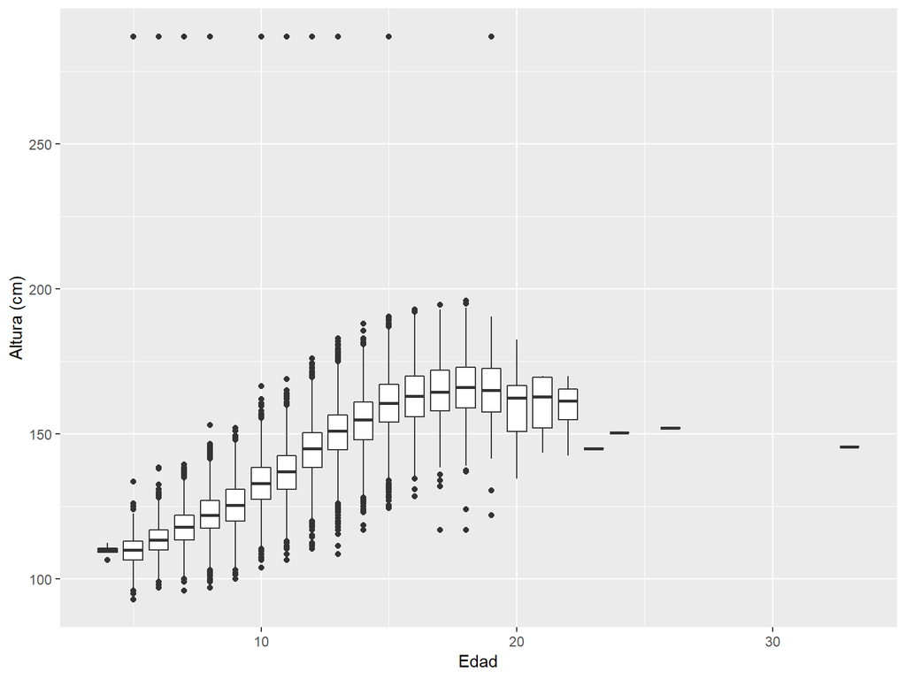

Las alturas de mas de 250 cm no tienen sentido. Adem?s, las edades mayores a 22 años tienen muy pocos datos. Se decidio removerlos:

```r
completeData <- completeData %>%
  filter(Height < 250) %>%
  filter(age < 23)
```

Gr?fica de boxplots de altura por edades sin outliers:

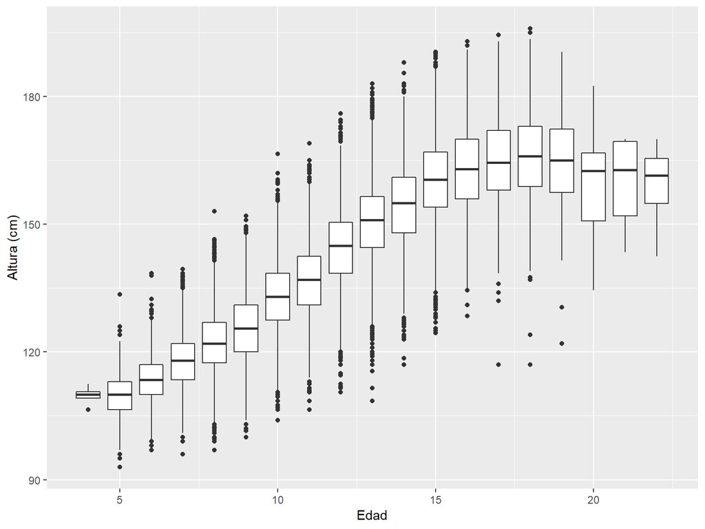

Grafica de boxplots de pesos por edades:

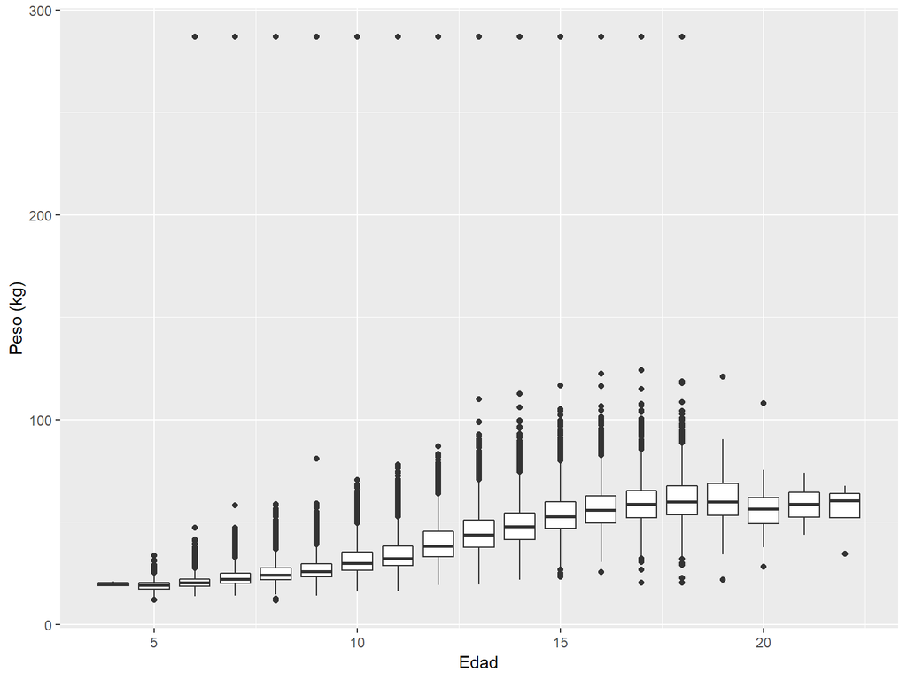

Pesos mayores a 200 kg no tienen sentidos. Se decidio eliminarlos:

```r
completeData <- completeData %>%
  filter(Weight < 200)
```

Grafica de boxplots de pesos por edades sin outliers:

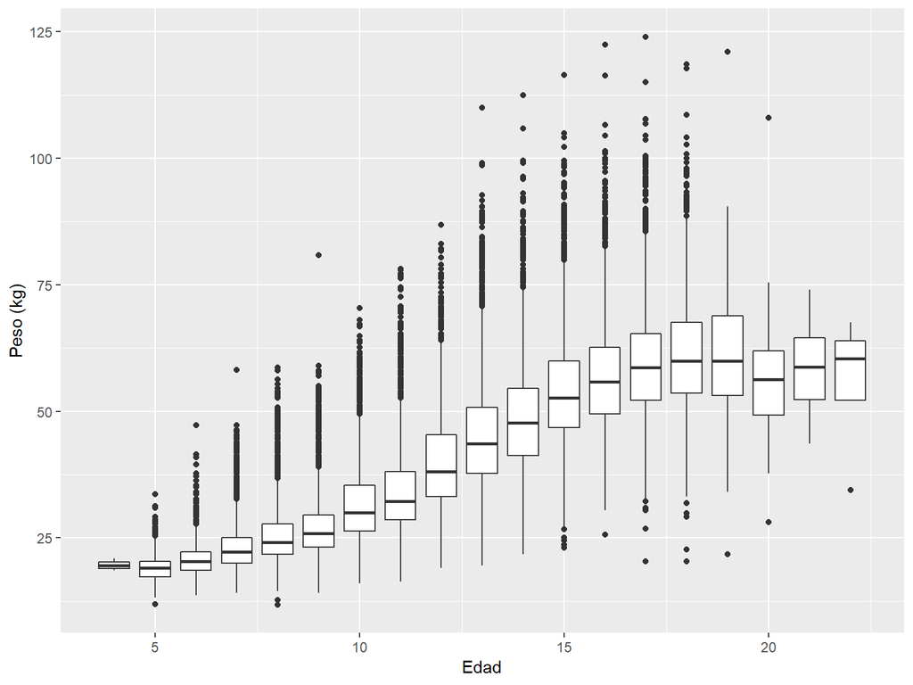

```r
ggplot(completeData, aes(group = age, x = age, y = Weight)) +
  geom_boxplot() +
  labs(x = "Edad", y = "Peso (kg)")
```

Graficas de regresion lineal entre peso y altura por edad:

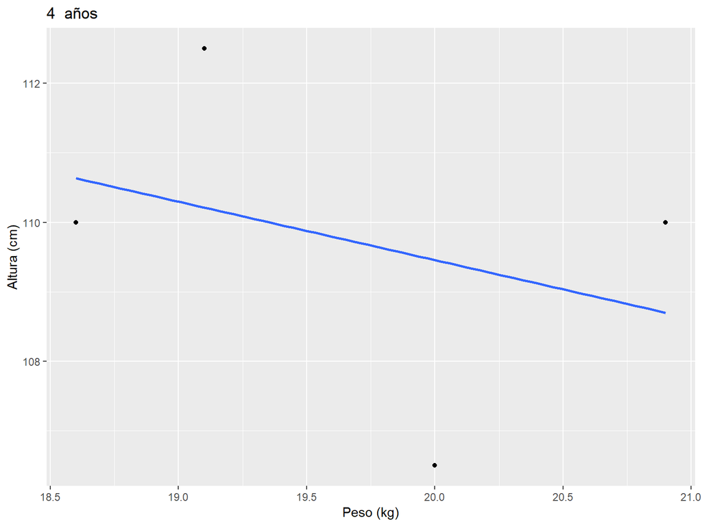

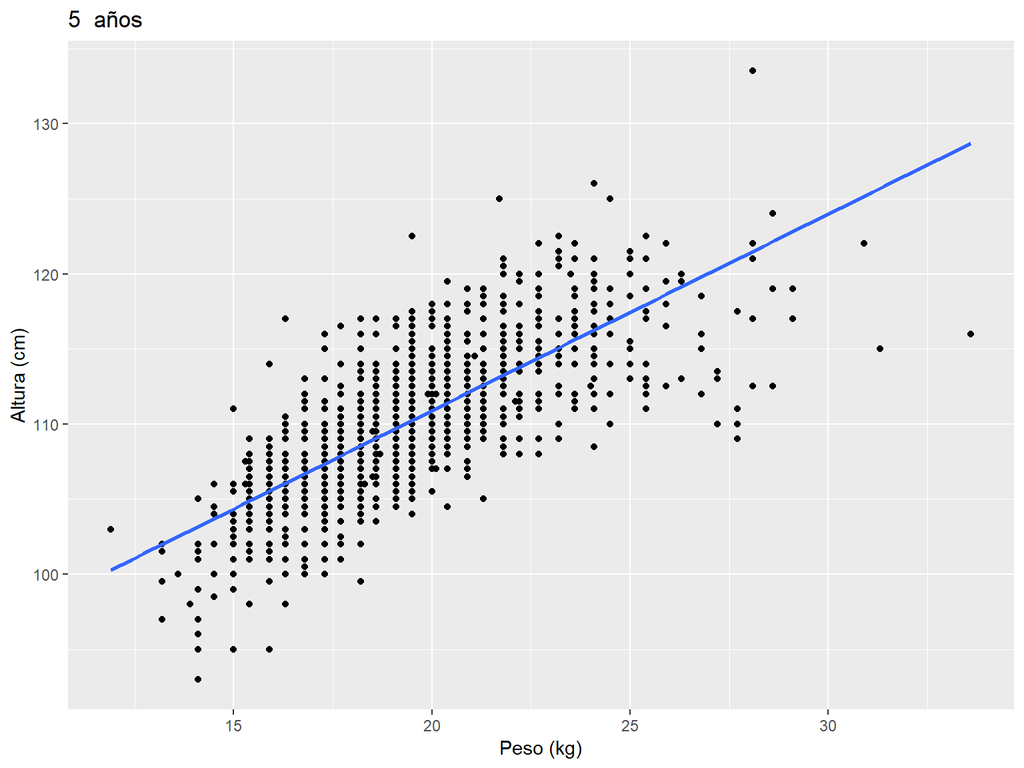

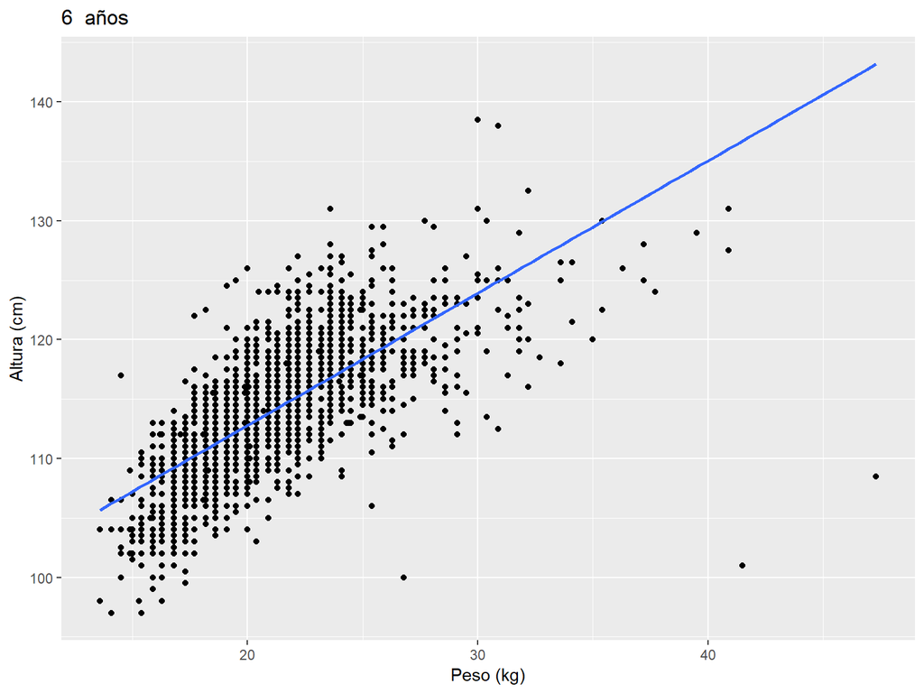

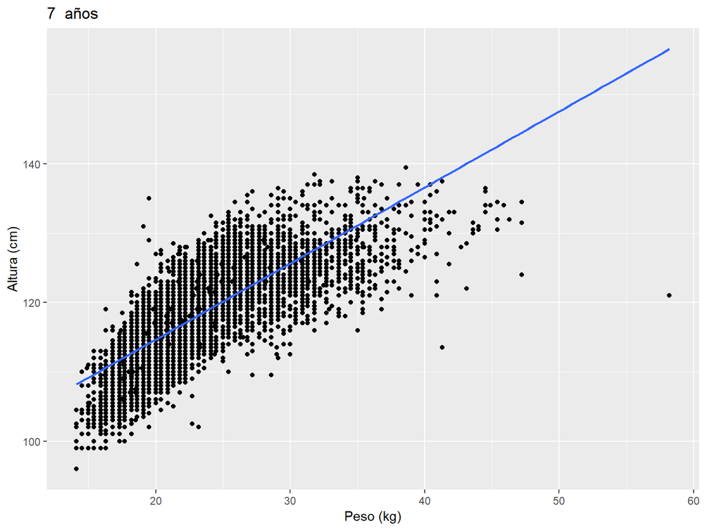

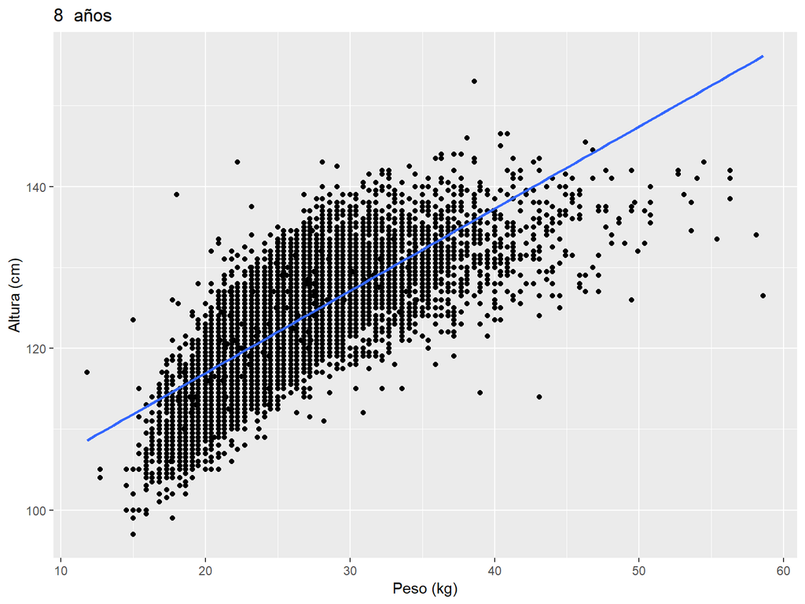

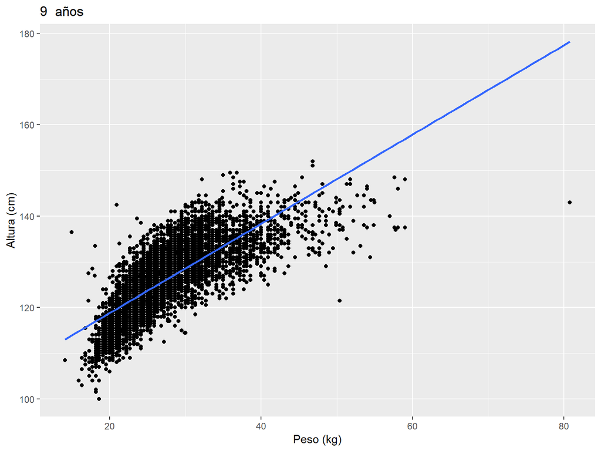

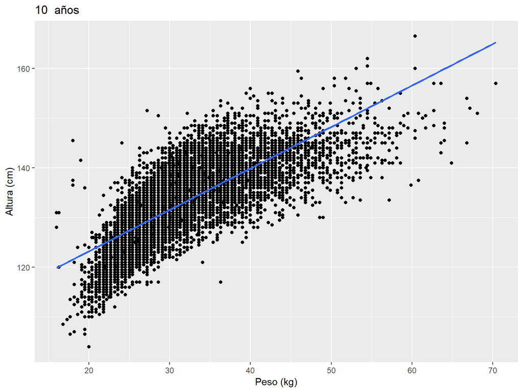

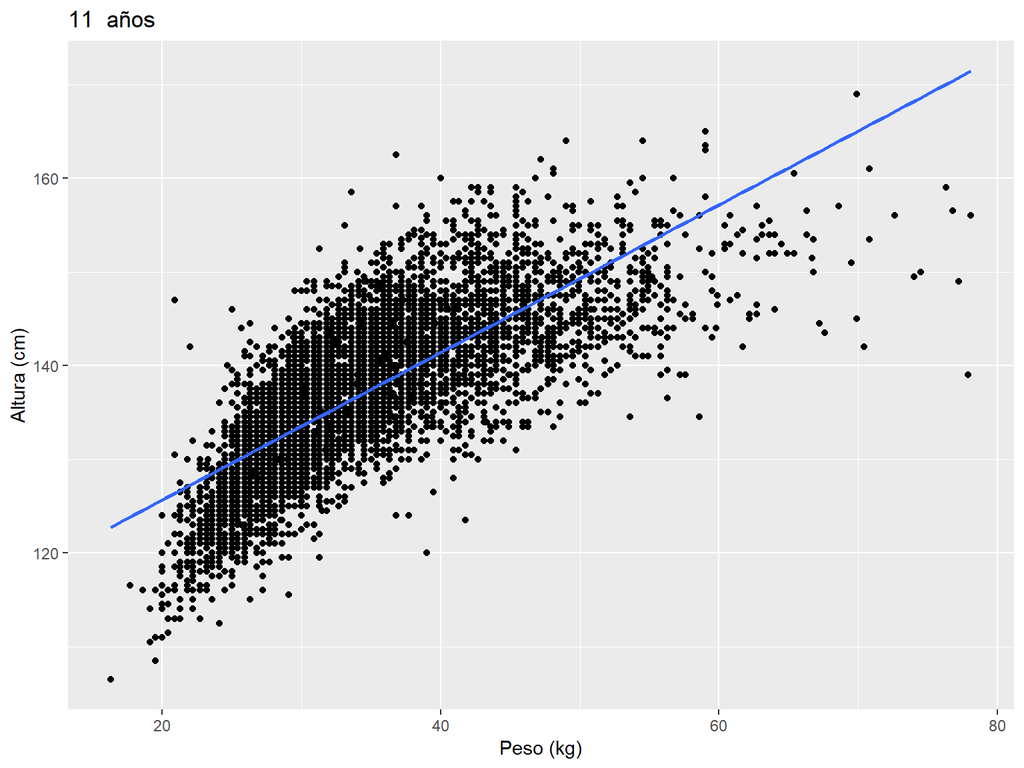